# {introverse} quick docs

`ggplot2::geom_smooth()`  
**`get_help()` docs**

### Description

The [`geom_smooth()`](https://ggplot2.tidyverse.org/reference/geom_smooth.html) function is part of the [`{ggplot2}`](https://ggplot2.tidyverse.org/) package, which is part of the [`{tidyverse}`](https://www.tidyverse.org/).

The `geom_smooth()` function is used to add a *trendline* to a plot, commonly to a scatterplot.

#### Required aesthetics:

- `x`: The x-axis coordinates to build the trendline from
- `y`: The y-axis coordinates to build the trendline from

#### Commonly used optional aesthetics:

- `color` (`colour`): The color of the trendline
- `fill`: The fill of the confidence interval band
- `se`: Whether to include a confidence interval band in the trendline (specify `TRUE` or `FALSE`)
- `method`: Which statistical formula to use to create the trendline. **To specify a linear trend line, use `method = "lm"`**, where “lm” stands for **l**inear **m**odel. `{ggplot2}` will always print a message telling you which statistical formula was used.

To use this function, you need to either first load the `{ggplot2}` library, or always use the function with `ggplot2::geom_smooth()` notation.

```r
# Load the library
library(ggplot2)
# Or, load the full tidyverse:
library(tidyverse)

# Or, use :: notation
ggplot2::geom_smooth()
```

### Examples

The examples below use the `msleep` dataset. Learn more about this dataset with `get_help("msleep")`.

```r
# Show the msleep dataset with head()
head(msleep)
```

```
## # A tibble: 6 × 11
##   name  genus vore  order conservation sleep_total sleep_rem sleep_cycle awake  brainwt  bodywt
##   <chr> <chr> <chr> <chr> <chr>              <dbl>     <dbl>       <dbl> <dbl>    <dbl>   <dbl>
## 1 Owl … Aotus omni  Prim… <NA>                17         1.8      NA       7    0.0155    0.48
## 2 Moun… Aplo… herbi Rode… nt                  14.4       2.4      NA       9.6 NA         1.35
## 3 Grea… Blar… omni  Sori… lc                  14.9       2.3       0.133   9.1  0.00029   0.019
## 4 Cow   Bos   herbi Arti… domesticated         4         0.7       0.667  20    0.423   600
## 5 Thre… Brad… herbi Pilo… <NA>                14.4       2.2       0.767   9.6 NA         3.85
## 6 Nort… Call… carni Carn… vu                   8.7       1.4       0.383  15.3 NA        20.5
```

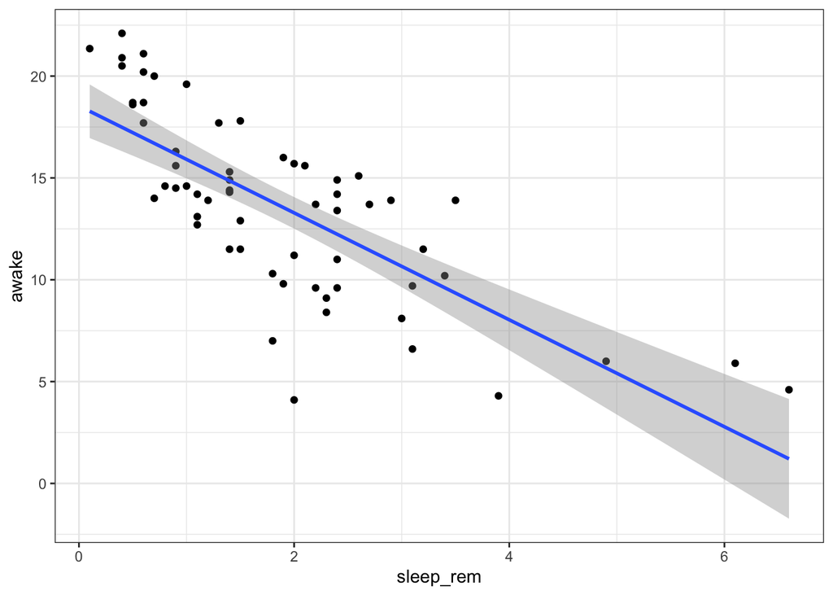

```r
# Scatterplot of awake against sleep_rem ("y against x") with a linear model trendline
ggplot(msleep) +
  aes(x = sleep_rem, y = awake) +
  geom_point() +
  geom_smooth(method = "lm")
```

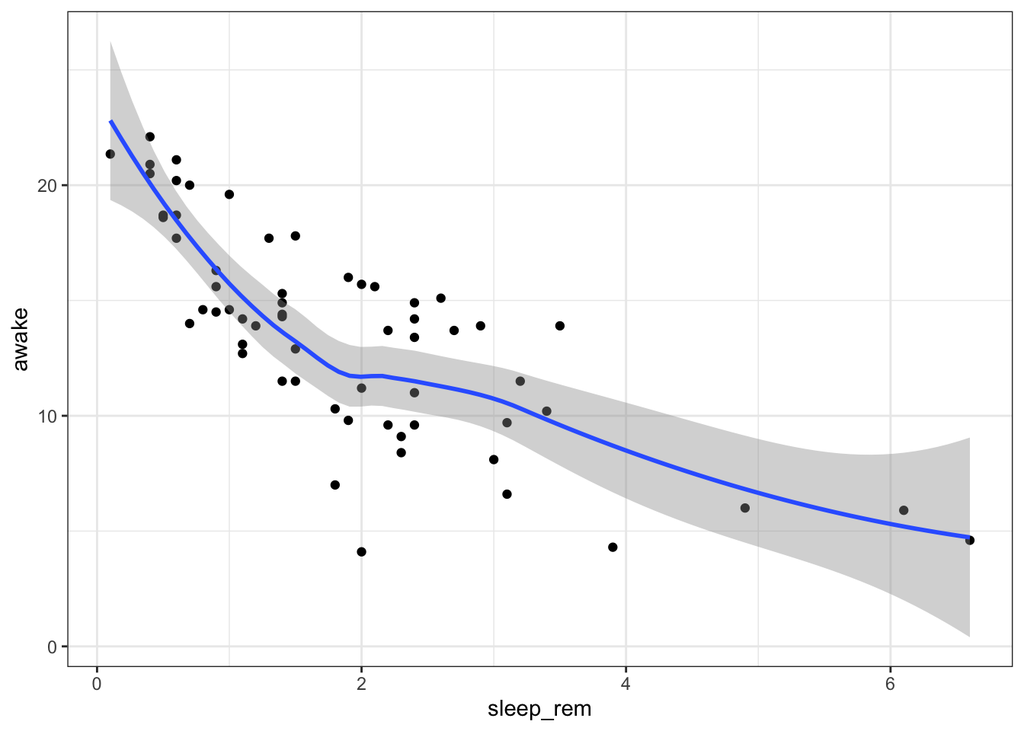

```r
## CAUTION! If you forget the argument `method = "lm"`, you will get a "loess trendline,"
# This is only a problem if you do not want a loess trendline
ggplot(msleep) +
  aes(x = sleep_rem, y = awake) +
  geom_point() +
  geom_smooth()
```

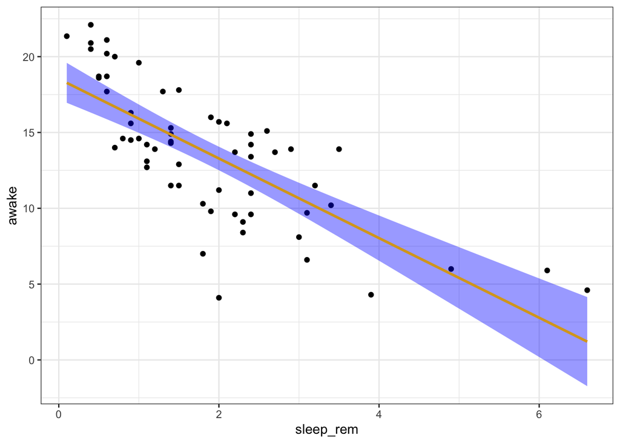

```r
# Scatterplot of awake against sleep_rem with custom linear trendline color and fill
ggplot(msleep) +
  aes(x = sleep_rem, y = awake) +
  geom_point() +
  geom_smooth(method = "lm",
              color = "goldenrod",
              fill = "blue")
```

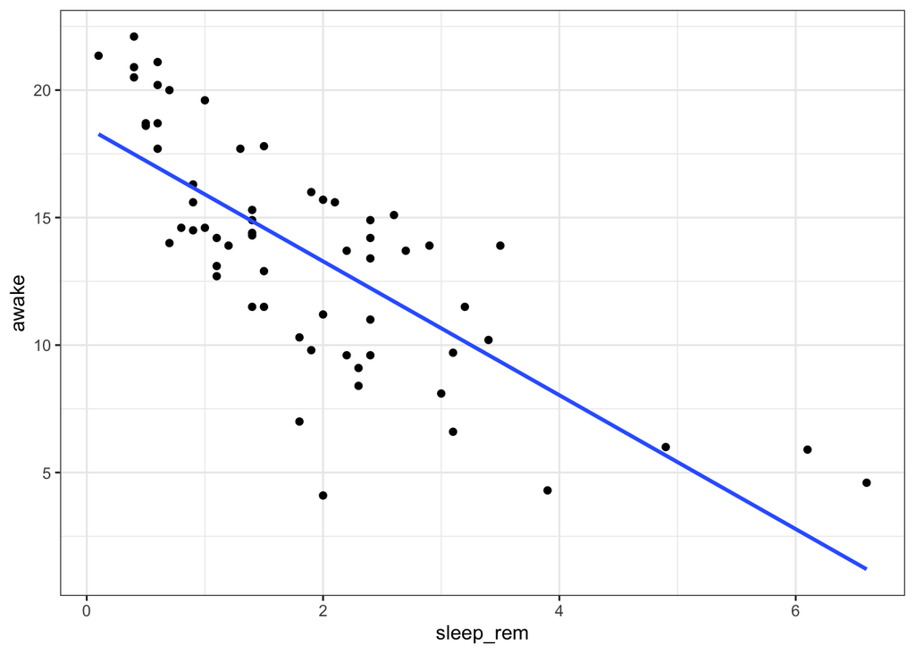

```r
# Scatterplot of awake against sleep_rem with confidence interval turned off
ggplot(msleep) +
  aes(x = sleep_rem, y = awake) +
  geom_point() +
  geom_smooth(method = "lm",
              se=FALSE)
```

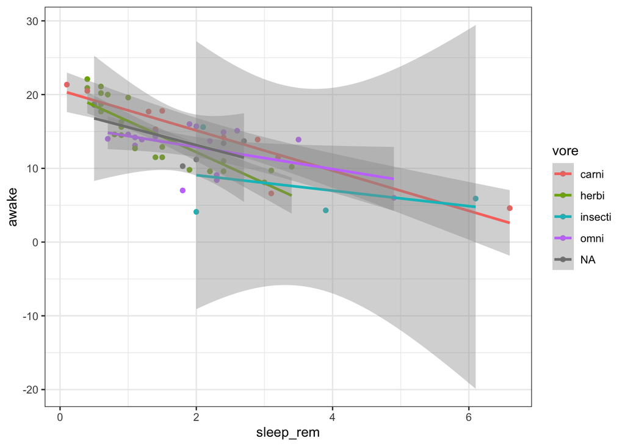

```r
# Points are colored by vore, specified in the shared `aes()`.
# geom_smooth inherits this aesthetic to create separate trendlines for each vore
ggplot(msleep) +
  aes(x = sleep_rem, y = awake, color = vore) +
  geom_point() +
  geom_smooth(method = "lm")
```

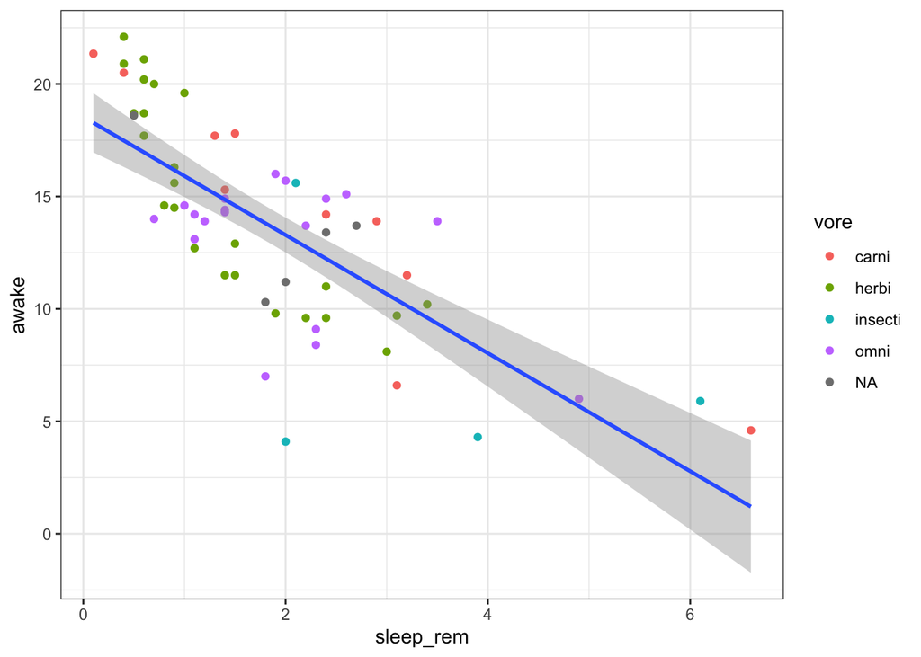

```r
# Points are colored by vore, specified in `geom_point()` only.
# geom_smooth will NOT inherit this aesthetic, and it creates a single trendline
ggplot(msleep) +
  aes(x = sleep_rem, y = awake) +
  geom_point(aes(color = vore)) +
  geom_smooth(method = "lm")
```